# Home Credit Default Risk

Rashi Jain, Surya Pavan Malireddy, Priya Rangarajan, Shashikant Jaiswal

July 20, 2018

### Overview

##### We are interested in predicting the clients’ repayment abilities with a variety of variables that are available. We make use of the Home Credit default risk from kaggle in predicting the defaulters.We make use of the training data provided and perform pre- processing and Exploratory data analysis.

##### https://www.kaggle.com/c/home-credit-default-risk

### 1. Set working directory and load the application_train.csv file

##### setting the blank values of the dataset as NA with the help of [na.strings = c(“NA”,“na”,’’)]

```r
loan.data <- read.csv(file="application_train.csv", header=TRUE, sep=",",na.strings = c("NA","na",''))
```

##### including all the libraries

```r
library(ggplot2)
library(e1071)
library(plyr)
library(knitr)
library(mice)
library(VIM)
```

```r
summary(loan.data)
```

```
##    SK_ID_CURR         TARGET              NAME_CONTRACT_TYPE CODE_GENDER
##  Min.   :100002   Min.   :0.00000   Cash loans     :278232   F  :202448
##  1st Qu.:189146   1st Qu.:0.00000   Revolving loans: 29279   M  :105059
##  Median :278202   Median :0.00000                            XNA:     4
##  Mean   :278181   Mean   :0.08073
##  3rd Qu.:367143   3rd Qu.:0.00000
##  Max.   :456255   Max.   :1.00000
##
##  FLAG_OWN_CAR FLAG_OWN_REALTY  CNT_CHILDREN    AMT_INCOME_TOTAL
##  N:202924     N: 94199        Min.   : 0.000   Min.   :    25650
##  Y:104587     Y:213312        1st Qu.: 0.000   1st Qu.:   112500
##                               Median : 0.000   Median :   147150
##                               Mean   : 0.418   Mean   :   168798
##                               3rd Qu.: 1.000   3rd Qu.:   202500
##                               Max.   :19.000   Max.   :117000000
##                               NA's   :687
##    AMT_CREDIT                  NAME_INCOME_TYPE
##  Min.   :  45000   Working             :158774
##  1st Qu.: 270000   Commercial associate: 71617
##  Median : 513531   Pensioner           : 55362
##  Mean   : 599026   State servant       : 21703
##  3rd Qu.: 808650   Unemployed          :    22
##  Max.   :4050000   Student             :    18
##                    (Other)             :    15
##                     NAME_EDUCATION_TYPE            NAME_FAMILY_STATUS
##  Academic degree              :   164   Civil marriage      : 29775
##  Higher education             : 74863   Married             :196432
##  Incomplete higher            : 10277   Separated           : 19770
##  Lower secondary              :  3816   Single / not married: 45444
##  Secondary / secondary special:218391   Unknown             :     2
##                                         Widow               : 16088
##
##            NAME_HOUSING_TYPE    DAYS_BIRTH     DAYS_EMPLOYED
##  Co-op apartment    :  1122   Min.   :-25229   Min.   :-17912
##  House / apartment  :272868   1st Qu.:-19682   1st Qu.: -2760
##  Municipal apartment: 11183   Median :-15750   Median : -1213
##  Office apartment   :  2617   Mean   :-16037   Mean   : 63815
##  Rented apartment   :  4881   3rd Qu.:-12413   3rd Qu.:  -289
##  With parents       : 14840   Max.   : -7489   Max.   :365243
##
##    FLAG_MOBIL FLAG_EMP_PHONE      OCCUPATION_TYPE
##  Min.   :0    Min.   :0.0000   Laborers   :55186
##  1st Qu.:1    1st Qu.:1.0000   Sales staff:32102
##  Median :1    Median :1.0000   Core staff :27570
##  Mean   :1    Mean   :0.8199   Managers   :21371
##  3rd Qu.:1    3rd Qu.:1.0000   Drivers    :18603
##  Max.   :1    Max.   :1.0000   (Other)    :56288
##                                NA's       :96391
```

### 3. Missing Values - analyze missing values in the data

```r
sapply(loan.data, function(x) sum(is.na(x)))
```

```
##          SK_ID_CURR              TARGET  NAME_CONTRACT_TYPE
##                   0                   0                   0
##         CODE_GENDER        FLAG_OWN_CAR     FLAG_OWN_REALTY
##                   0                   0                   0
##        CNT_CHILDREN    AMT_INCOME_TOTAL          AMT_CREDIT
##                 687                   0                   0
##    NAME_INCOME_TYPE NAME_EDUCATION_TYPE  NAME_FAMILY_STATUS
##                   0                   0                   0
##   NAME_HOUSING_TYPE          DAYS_BIRTH       DAYS_EMPLOYED
##                   0                   0                   0
##          FLAG_MOBIL      FLAG_EMP_PHONE     OCCUPATION_TYPE
##                   0                   0               96391
```

##### As per the output of sapply(), The columns CNT_CHILDREN and OCCUPATION_TYPE have missing values.

##### CNT_CHILDREN - 687 missing values

##### OCCUPATION_TYPE - 96391 missing values

### 4. Create a box plot comparing AMT_INCOME_TOTAL and AMT_CREDIT are there outliers that should be removed based on the resulting box plot?

##### Plot for Amount Income grouped by Income Type

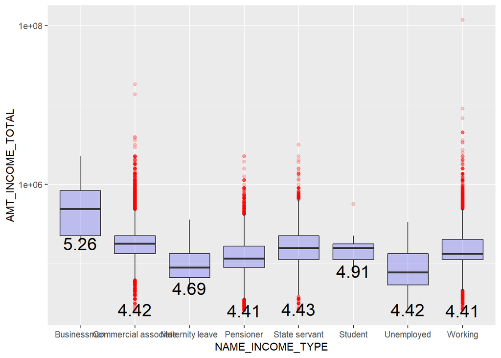

```r
ggplot(loan.data,aes(NAME_INCOME_TYPE ,AMT_INCOME_TOTAL,group=NAME_INCOME_TYPE))+
  geom_boxplot(alpha=0.2,fill="blue",outlier.colour ="red" )+
  scale_y_log10()+stat_summary(aes(label=round(..y..,2)), fun.y=min,geom="text", size=6)
```

#####Box-plot of amount Income grouped by Income type. There are outliers as shown by the box-plot that must be removed

##### Plot for Amount Credit grouped by gender

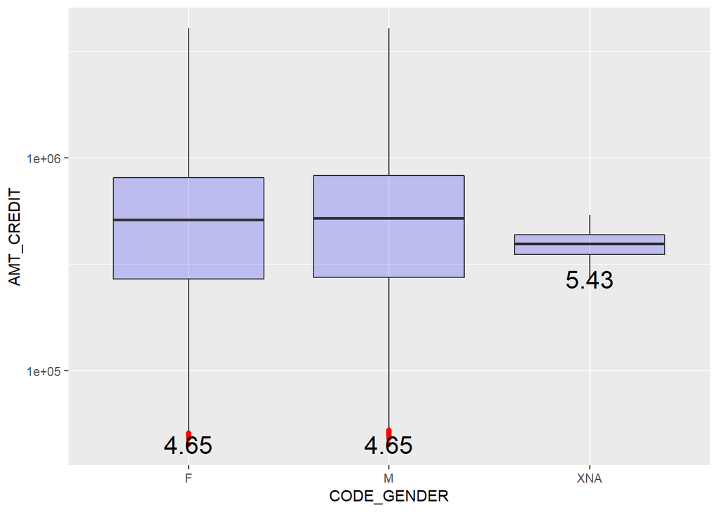

```r
ggplot(loan.data,aes(CODE_GENDER ,AMT_CREDIT,group=CODE_GENDER))+
  geom_boxplot(alpha=0.2,fill="blue",outlier.colour ="red" )+
  scale_y_log10()+stat_summary(aes(label=round(..y..,2)), fun.y=min,geom="text", size=6)
```

### 5. Create flag variables for the NAME_FAMILY_STATUS categorical attribute

```r
loan.data$FamilyStatus_Single_Flag <- 0
loan.data$FamilyStatus_Married_Flag <- 0
loan.data$FamilyStatus_CivilMarriage_Flag <- 0
loan.data$FamilyStatus_Widow_Flag <- 0
loan.data$FamilyStatus_Separated_Flag <- 0
```

##### NAME_FAMILY_STATUS will be ‘unknown’ when all flags are 0

```r
loan.data$FamilyStatus_Single_Flag[loan.data$NAME_FAMILY_STATUS == 'Single / not married'] = 1
loan.data$FamilyStatus_Married_Flag[loan.data$NAME_FAMILY_STATUS == 'Married'] = 1
loan.data$FamilyStatus_CivilMarriage_Flag[loan.data$NAME_FAMILY_STATUS == 'Civil marriage'] = 1
loan.data$FamilyStatus_Widow_Flag[loan.data$NAME_FAMILY_STATUS == 'Widow'] = 1
loan.data$FamilyStatus_Separated_Flag[loan.data$NAME_FAMILY_STATUS == 'Separated'] = 1
```

### 6. Standardize AMT_INCOME_TOTAL using Z-Score Standardization. Calculate skewness. Is the attribute normally distributed?

```r
sd_AMT_INCOME_TOTAL <- sd(loan.data$AMT_INCOME_TOTAL)
mean_AMT_INCOME_TOTAL <- mean(loan.data$AMT_INCOME_TOTAL)
sd_AMT_INCOME_TOTAL
```

```
## [1] 237123.1
```

```r
mean_AMT_INCOME_TOTAL
```

```
## [1] 168797.9
```

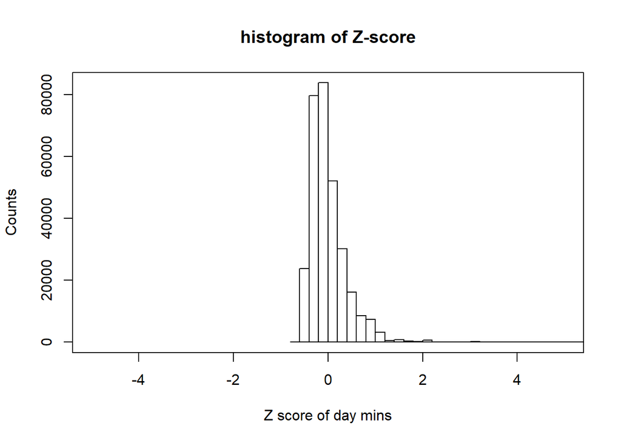

```r
zscore.AMT_INCOME_TOTAL <- (loan.data$AMT_INCOME_TOTAL - mean_AMT_INCOME_TOTAL) / sd_AMT_INCOME_TOTAL
par(mfrow=c(1,1))
hist(zscore.AMT_INCOME_TOTAL, breaks=3000,xlim=c(-5,5), main="histogram of Z-score",
     xlab="Z score of day mins",ylab="Counts")
box(which = "plot", lty="solid", col="black")
```

```r
zscore_AMT_INCOME_TOTAL_skew <- (3*(mean(zscore.AMT_INCOME_TOTAL)-median(zscore.AMT_INCOME_TOTAL))) / sd(zscore.AMT_INCOME_TOTAL)
zscore_AMT_INCOME_TOTAL_skew
```

```
## [1] 0.273882
```

##### Attribute AMT_INCOME_TOTAL is not normally distributed.Its skew value is 0.273882.

### 7. Analyze AMT_INCOME_TOTAL for Outliers using the Z-Score values. show both lower range and upper range outliers.

```r
length(zscore.AMT_INCOME_TOTAL[zscore.AMT_INCOME_TOTAL>3])
```

```
## [1] 454
```

```r
length(zscore.AMT_INCOME_TOTAL[zscore.AMT_INCOME_TOTAL<-3])
```

```
## [1] 1
```

### 8. Standardize AMT_CREDIT using Z-Score Standardization. Calculate skewness. Is the attribute normally distributed?

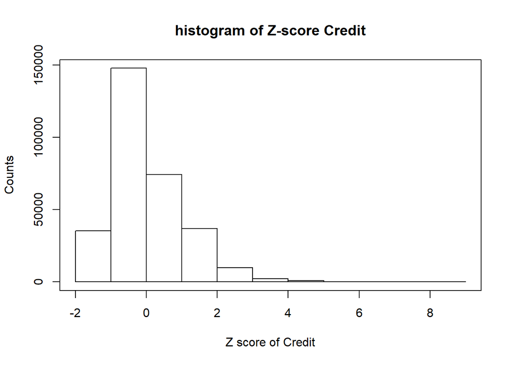

```r
pop_sd_credit <- sd(loan.data$AMT_CREDIT)*sqrt((length(loan.data$AMT_CREDIT)-1)/(length(loan.data$AMT_CREDIT)))
pop_mean_credit <- mean(loan.data$AMT_CREDIT)
zscore.credit <- ( loan.data$AMT_CREDIT- pop_mean_credit) / pop_sd_credit
hist(zscore.credit, breaks=11,main="histogram of Z-score Credit",
     xlab="Z score of Credit",ylab="Counts")
box(which = "plot", lty="solid", col="black")
```

```r
credit_skew <- (3*(mean(zscore.credit)-median(zscore.credit))) / sd(zscore.credit)
credit_skew
```

```
## [1] 0.6372444
```

##### The AMT_CREDIT is not normally distributed with a skewness of 0.6

### 9. Analyze AMT_CREDIT for Outliers using the Z-Score values. Show both the lower range and upper range outliers

```r
length(zscore.credit[zscore.credit < -3])
```

```
## [1] 0
```

```r
length(zscore.credit[zscore.credit >3])
```

```
## [1] 3255
```

##### 3255 outliers lie 3 standard deviations away from the mean

### 10. Using knowledge from 4 through 9, make a decision on removing outliers and transforming for normality in the two attributes and document your decision

##### The data for the two variables is right skewed

##### To eliminate skewness and to achieve normality we should use the common transformations like Natural log, square root and inverse square root after this check for the normal probability plot(plot quantiles)

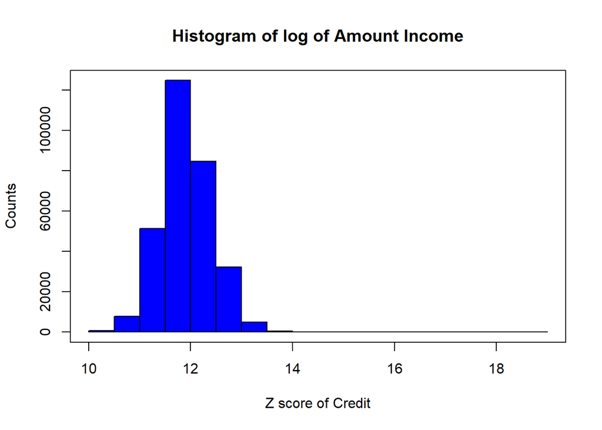

```r
hist(log(loan.data$AMT_INCOME_TOTAL), breaks=15,main="Histogram of log of Amount Income",
     xlab="Z score of Credit",ylab="Counts",col="blue")
box(which = "plot", lty="solid", col="black")
```

```r
skewness(log(loan.data$AMT_INCOME_TOTAL))
```

```
## [1] 0.1699675
```

### 11. Use binning to discretize AMT_TOTAL_INCOME into five bins named A through E with A being the lowest and E being the highest - name the new attribute CAT_AMT_TOTAL_INCOME

```r
loan.data$CAT_AMT_INCOME_TOTAL <- cut(
  loan.data$AMT_INCOME_TOTAL,
  breaks = c(0, 100000,150000 ,200000 ,250000,117000000),
  labels = c("A", "B", "C", "D", "E"),
  right  = TRUE,
  include.lowest = TRUE
)
kable(table(loan.data$CAT_AMT_INCOME_TOTAL))
```

| Var1 | Freq |
| --- | --- |
| A | 63698 |
| B | 91591 |
| C | 64307 |
| D | 48137 |
| E | 39778 |

##### Equal width binning can lead to outliers being included in the bins.Equal width binning after outlier removal is thus recommended.

##### Normalization can reduce skewness which in turn is caused by outliers and binning after normalization may thus yield useful results.

##### Removing Outliers

```r
uif_amtincome<-quantile(loan.data$AMT_INCOME_TOTAL,.75)+1.5*IQR(loan.data$AMT_INCOME_TOTAL)
lif_amtincome<-quantile(loan.data$AMT_INCOME_TOTAL, .25)-1.5*IQR(loan.data$AMT_INCOME_TOTAL)
attach(loan.data)
loan1.data<-loan.data[AMT_INCOME_TOTAL<uif_amtincome&AMT_INCOME_TOTAL>lif_amtincome ,]
```

##### Binning without outliers

```r
loan1.data$CAT_AMT_INCOME_TOTAL <- cut(
  loan1.data$AMT_INCOME_TOTAL,
  breaks = c(0, 100000,150000 ,200000 ,250000,117000000),
  labels = c("A", "B", "C", "D","E"),
  right  = TRUE,
  include.lowest = TRUE
)

kable(table(loan1.data$CAT_AMT_INCOME_TOTAL))
```

| Var1 | Freq |
| --- | --- |
| A | 63698 |
| B | 91591 |
| C | 64307 |
| D | 48137 |
| E | 23953 |

### 11.a Observations about binning

##### 1. It is important to consult domain expert to know the income brackets to bin the variable accurately.

##### 2. Also, It is important to remove the outliers before binning so that maximum binnig accuracy is achieved. Outliers can heavily impact the binning process.

### 12. Use MICE to impute appropriate values for the missing values in CNT_CHILDREN (note: the actual value in each case was 0)

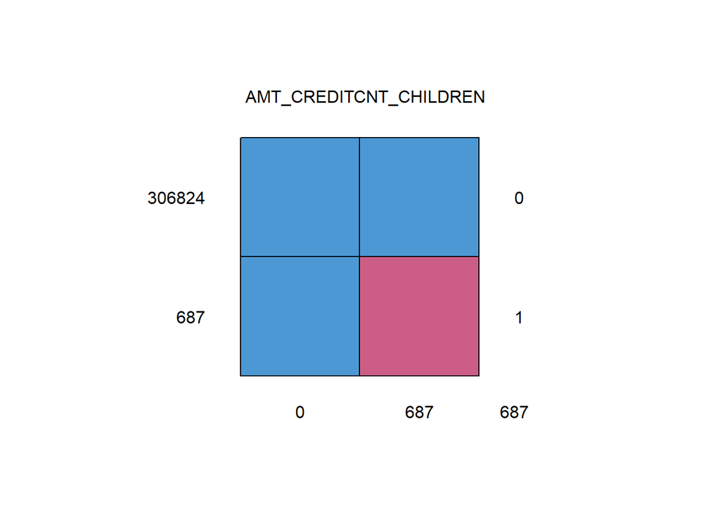

```
##        AMT_CREDIT CNT_CHILDREN
## 306824          1            1   0
## 687             1            0   1
##                 0          687 687
```

```r
loan.child <- subset(loan.data,select=c(CNT_CHILDREN,AMT_CREDIT))
md.pattern(loan.child)
```

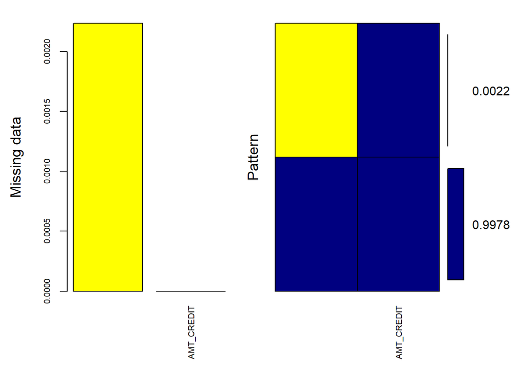

```
##
##  Variables sorted by number of missings:
##      Variable       Count
##  CNT_CHILDREN 0.002234066
##    AMT_CREDIT 0.000000000
```

```r
mice_plot <- aggr(loan.child, col=c('navyblue','yellow'),
                  numbers=TRUE, sortVars=TRUE,
                  labels=names(loan.child), cex.axis=.7,
                  gap=3, ylab=c("Missing data","Pattern"))
```

```r
imputed_Data <- mice(loan.child, m=2, maxit = 2, method = 'pmm', seed = 500)
summary(imputed_Data)
```

```
## Class: mids
## Number of multiple imputations:  2
## Imputation methods:
## CNT_CHILDREN   AMT_CREDIT
##        "pmm"           ""
## PredictorMatrix:
##              CNT_CHILDREN AMT_CREDIT
## CNT_CHILDREN            0          1
## AMT_CREDIT              1          0
```

### 13 Use the table command to create a contingency table of your choice

```r
contingency_table1  <- table(loan.data$NAME_EDUCATION_TYPE,loan.data$NAME_HOUSING_TYPE)
kable(contingency_table1)
```

|  | Co-op apartment | House / apartment | Municipal apartment | Office apartment | Rented apartment | With parents |
| --- | --- | --- | --- | --- | --- | --- |
| Academic degree | 2 | 147 | 1 | 3 | 6 | 5 |
| Higher education | 489 | 66862 | 1688 | 801 | 1063 | 3960 |
| Incomplete higher | 60 | 8366 | 307 | 97 | 312 | 1135 |
| Lower secondary | 10 | 3187 | 277 | 41 | 79 | 222 |
| Secondary / secondary special | 561 | 194306 | 8910 | 1675 | 3421 | 9518 |

### 14 Get a count of the n way frequency for pairs

```r
sumtable <- addmargins(contingency_table1, FUN=sum)
```

```
## Margins computed over dimensions
## in the following order:
## 1:
## 2:
```

```r
kable(sumtable)
```

|  | Co-op apartment | House / apartment | Municipal apartment | Office apartment | Rented apartment | With parents | sum |
| --- | --- | --- | --- | --- | --- | --- | --- |
| Academic degree | 2 | 147 | 1 | 3 | 6 | 5 | 164 |
| Higher education | 489 | 66862 | 1688 | 801 | 1063 | 3960 | 74863 |
| Incomplete higher | 60 | 8366 | 307 | 97 | 312 | 1135 | 10277 |
| Lower secondary | 10 | 3187 | 277 | 41 | 79 | 222 | 3816 |
| Secondary / secondary special | 561 | 194306 | 8910 | 1675 | 3421 | 9518 | 218391 |
| sum | 1122 | 272868 | 11183 | 2617 | 4881 | 14840 | 307511 |

### 15 Is the data realistic for DAYS_BIRTH and DAYS_EMPLOYED? Why or why not?

##### create a column to compute the age take the absolute values since the data has negative values

```r
loan.data$Age <- 0
loan.data$Age <- abs(loan.data$DAYS_BIRTH)/365
```

##### create a column to compute the number of working years take the absolute values since the data has negative values

```r
loan.data$Working_years <- 0
loan.data$Working_years <- abs(loan.data$DAYS_EMPLOYED)/365
```

##### check if the data is appropriate by comparing the age and the number of working years

```r
loan.data$isValid <-0
loan.data$isValid[loan.data$Age > loan.data$Working_years ] = 1
loan.data$isValid[loan.data$Age <= loan.data$Working_years ] = 0
table(loan.data$isValid)
```

```
##
##      0      1
##  55374 252137
```

##### we found some of the values as 0 i.e. number of working years> age which is not realistic.So, we can say that the data is not valid as DAYS_BIRTH and DAYS_EMPLOYED are negative numbers and in some of the cases, the value of DAYS_EMPLOYED is also greater than the DAYS_BIRTH

### 16 What else would you like to do with the data in order to complete EDA and Pre-processing? What have you learned?

##### We need to check all the variables of the dataset in order to preprocess them(check for missing values)

##### Removing duplicate records

##### Adding index field, Binning numerical variables

##### Changing categorical variables to flag variables

##### draw the plots for all the variables and find the outliers

##### Deal with the outliers if exists

##### calculate the skewness, the data is perfectly symmetric if skewness is 0.

##### if the data is skewed, then we need to apply transformation to the data to achieve the normality like natural log, square root or inverse square root

##### we can plot the normal distributed curve to check for the normality.